# Section 1: Data Cleaning

## Import datasets into project and join by shared columns

```python
# Import OS for accesing system folders
import os as os

# Import Pandas for conversion of .csv into dataframes and usage of Pandas library
import pandas as pd
import numpy as np

import warnings
warnings.filterwarnings('ignore')
```

```python
# Set folder_path from our current directory
folder_path = os.getcwd()

# Update folder_path to Data/ folder to access .csv files
folder_path = os.path.join(folder_path, r"Data")
```

```python
# Check that the files needed are in the folder
os.listdir(folder_path)
```

```
['2012_cleaned.csv', '2013_cleaned.csv', '2014_cleaned.csv']
```

### Our first issue with these tables is that not all of them possess the same columns (only the names are the same). Therefore, we need to extract only the columns that all three tables have in common to avoid problems when merging into a bigger dataframe.

```python
# Proof: columns are different for each .csv

# Loop through each file by name of files as in:
# ['2012_cleaned.csv', '2013_cleaned.csv', '2014_cleaned.csv']
for file_name in os.listdir(folder_path):
    current_file_path = os.path.join(folder_path, file_name)
    current_df = pd.read_csv(
        current_file_path
    )  # Convert the current .csv into a df to use Pandas columns() module
    print(
        file_name, "has", len(current_df.columns), "columns"
    )  # Check columns are not equal just by looking at amount of columns in each table
```

```
2012_cleaned.csv has 29 columns
2013_cleaned.csv has 28 columns
2014_cleaned.csv has 37 columns
```

### Our first table has 29, our second 28, and our last one 37. When adding the tables, this will result in columns with many NA values. We must eliminate the "extra" columns first.

```python
# Run a similar loop as above to created a nested list of all columns, to intersect later

columns_in_tables = []

for file_name in os.listdir(folder_path):
    current_file_path = os.path.join(folder_path, file_name)
    current_df = pd.read_csv(current_file_path)

    # Put all columns for each column in the list created above
    # Will look something like the following:
    # [[table1_column1][table1_column2],[table2_column1]...,[table3_column3]...]
    columns_in_tables.append(current_df.columns)
```

```python
# For finding which columns are in every table we need to run an intersection
# Python does this by turning a nested list into a list of sets.

shared_columns = list(
    set.intersection(*map(set, columns_in_tables))
)  # * as in *args for multiple arguments input
# The map() function turns each element (sublist of columns) into a set which
# We then turn the set back into a list and store it in shared_columns
```

```python
# Modify the above for loop to put all tables in a single dataframe and select only shared_columns

data_merge = pd.DataFrame()  # Initialize empty df
dataframes = []  # Initialize empty list for use in pd.concat which accepts lists only

for file_name in os.listdir(folder_path):
    current_file_path = os.path.join(folder_path, file_name)
    current_df = pd.read_csv(current_file_path)
    dataframes.append(current_df)

data_merge = pd.concat(dataframes)
data_merge = data_merge[list(shared_columns)]
```

### We can now see the columns we have to work with.

```python
data_merge.columns
```

```
Index(['marriage', 'pre_ele_101', 'wsel', 'zip', 'year', 'religion', 'id',
       'ssu', 'taiwanese_or_chinese', 'edu', 'gender', 'pre_ele_97', 'psu',
       'birth_year', 'mothe_house_income', 'political_party', 'year_m',
       'stratum2', 'wave', 'month_income', 'taiwan_indep', 'qtype'],
      dtype='object')
```

### And eliminate those which we don't need

```python
data_merge = data_merge.drop(
    columns=["year_m", "wave", "psu", "wsel", "id", "qtype", "ssu"]
)
```

## Normalizing of variables in each column for easier navigation.

### We now need to see which values columns have and normalize those values into simpler categories. For example: The political_party columns has the following values which, for this analysis, are too many.

```python
data_merge["political_party"].value_counts()
```

| political_party | count |
| --- | --- |
| 都沒有___都支持 | 1165 |
| 都差不多 | 1115 |
| 都沒有/都支持 | 838 |
| 跳答 | 749 |
| 國民黨 | 605 |
| 民進黨 | 406 |
| 國民黨(跳答h7) | 249 |
| 民進黨(跳答h7) | 203 |
| 泛藍 | 131 |
| 泛綠 | 114 |
| 不知道 | 95 |
| 拒答 | 86 |
| 無黨籍(跳答h7) | 41 |
| 有偏向政黨,不願意回答 | 21 |
| 親民黨 | 13 |
| 親民黨(跳答h7) | 12 |
| 有支持政黨,但不回答 | 12 |
| 綠黨 | 12 |
| 台聯黨 | 9 |
| 其他政黨,請說明 | 8 |
| 新黨 | 7 |
| 新黨(跳答h7) | 3 |
| 台聯(跳答h7) | 2 |
| 其他 | 1 |
| 建國黨 | 1 |
| 台聯 | 1 |

**dtype:** int64

### Or the birth_year column has non-numeric values

```python
data_merge.dtypes
# Int and floats are numeric while object are usually a combination of strings, ints, etc...
```

|  | 0 |
| --- | --- |
| marriage | object |
| pre_ele_101 | object |
| zip | object |
| year | int64 |
| religion | object |
| taiwanese_or_chinese | object |
| edu | object |
| gender | object |
| pre_ele_97 | object |
| birth_year | object |
| mothe_house_income | object |
| political_party | object |
| stratum2 | object |
| month_income | object |
| taiwan_indep | object |

**dtype:** object

```python
# Let's extract columns where birth_year is only numbers...
# Run to_numeric to try and convert to number, if not possible then return NA, then use notnull to return non-NA values
# i.e. Return only numbers
data_merge = data_merge[
    pd.to_numeric(data_merge["birth_year"], errors="coerce").notnull()
]
data_merge["birth_year"] = data_merge["birth_year"].astype("int")
```

### Most of the columns will only require some renaming of variables into categories (e.g. "M" and "Male" should only be one category "Male). A simple example of renaming can be seen as follows.

```python
data_merge.loc[data_merge["gender"] == "男", "gender"] = (
    "Male"  # Find the values on the left and assign the value on the right

)
data_merge.loc[data_merge["gender"] == "女", "gender"] = "Female"


# Create categories list in order desired (Order can be ignored later.)

gender_categories = ["男性", "女性"]


data_merge["gender"] = pd.Categorical(
    data_merge["gender"], categories=gender_categories
)


data_merge["gender"].unique()
```

```
[NaN, '男性', '女性']
Categories (2, object): ['男性', '女性']
```

### We start by cleaning the political_party target column.

```python
# Define the values to be replaced and the replacement string
data_merge.loc[
    data_merge["political_party"].isin(["民進黨(跳答h7)", "泛綠", "民進黨"]),
    "political_party",
] = "DPP"
data_merge.loc[
    data_merge["political_party"].isin(["國民黨(跳答h7)", "泛藍", "國民黨"]),
    "political_party",
] = "KMT"

# Change all other values to 'other'
data_merge.loc[
    ~data_merge["political_party"].isin(["DPP", "KMT"]), "political_party"
] = "Other"
data_merge["political_party"].unique()
```

```
array(['Other', 'DPP', 'KMT'], dtype=object)
```

### Do a similar process for our ethnic identification column. From this:...

```python
# Output all values of the ethnic identification category
data_merge["taiwanese_or_chinese"].unique()
```

```
array(['台灣人', '都是', '都不是', '中國人', '拒答', '不知道', '其他', '兩者都是', '兩者都不是,請說明',
       '無法決定', '兩者都是:是台灣人也是中國人', '兩者都是:是中國人也是台灣人', '都不是,請說明', '無法選擇',
       '不瞭解題意'], dtype=object)
```

### To this:

```python
data_merge["taiwanese_or_chinese"].value_counts()
```

| taiwanese_or_chinese | count |
| --- | --- |
| 台灣人 | 3985 |
| 都是 | 642 |
| 兩者都是 | 472 |
| 兩者都是:是台灣人也是中國人 | 455 |
| 中國人 | 144 |
| 兩者都是:是中國人也是台灣人 | 72 |
| 不知道 | 27 |
| 都不是 | 25 |
| 都不是,請說明 | 23 |
| 拒答 | 19 |
| 兩者都不是,請說明 | 14 |
| 其他 | 8 |
| 無法選擇 | 7 |
| 無法決定 | 3 |
| 不瞭解題意 | 1 |

**dtype:** int64

```python
both_categories = [
    "都是",
    "兩者都是",
    "兩者都是:是中國人也是台灣人",
    "兩者都是:是台灣人也是中國人",
    "兩者",
]

data_merge.loc[
    data_merge["taiwanese_or_chinese"] == "中國人", "taiwanese_or_chinese"
] = "Chinese"

data_merge.loc[
    data_merge["taiwanese_or_chinese"] == "台灣人", "taiwanese_or_chinese"
] = "Taiwanese"

data_merge.loc[
    data_merge["taiwanese_or_chinese"].isin(both_categories), "taiwanese_or_chinese"
] = "Both"

data_merge.loc[
    data_merge["taiwanese_or_chinese"].isin(["不知道", "拒答", "無法選擇", "無法決定", "不瞭解題意"]),
    "taiwanese_or_chinese",
] = "Unclear"

data_merge.loc[
    ~data_merge["taiwanese_or_chinese"].isin(
        ["Taiwanese", "Chinese", "Both", "Unclear"]
    ),
    "taiwanese_or_chinese",
] = "Unclear"

data_merge["taiwanese_or_chinese"].value_counts()
```

| taiwanese_or_chinese | count |
| --- | --- |
| Taiwanese | 3985 |
| Both | 1641 |
| Chinese | 144 |
| Unclear | 127 |

**dtype:** int64

### For the other columns the process looks quite similar

```python
data_merge["pre_ele_101"].value_counts()

data_merge.loc[data_merge["pre_ele_101"].str.contains("蔡英文", na=False), "pre_ele_101"] = (
    "Tsai Ying-Wen"
)
data_merge.loc[data_merge["pre_ele_101"].str.contains("馬英九", na=False), "pre_ele_101"] = (
    "Ma Ying-Jiu"
)
data_merge.loc[
    data_merge["pre_ele_101"].str.contains("宋楚瑜|投廢票", na=False), "pre_ele_101"
] = "Other candidate / blank vote"
data_merge.loc[
    data_merge["pre_ele_101"].str.contains("沒有去投票|沒有投票權|當時未滿20歲", na=False),
    "pre_ele_101",
] = "Non-voter / ineligible"
data_merge.loc[
    data_merge["pre_ele_101"].str.contains("拒答|不知道|忘記|不願意回答", na=False),
    "pre_ele_101",
] = "Unclear"
data_merge.loc[
    ~data_merge["pre_ele_101"].isin(
        [
            "Tsai Ying-Wen",
            "Ma Ying-Jiu",
            "Other candidate / blank vote",
            "Non-voter / ineligible",
            "Unclear",
        ]
    ),
    "pre_ele_101",
] = "Unclear"
data_merge["pre_ele_101"].value_counts()
```

| pre_ele_101 | count |
| --- | --- |
| Ma Ying-Jiu | 2264 |
| Tsai Ying-Wen | 1571 |
| Non-voter / ineligible | 1292 |
| Unclear | 558 |
| Other candidate / blank vote | 212 |

**dtype:** int64

```python
data_merge.loc[data_merge["pre_ele_97"].str.contains("謝長廷", na=False), "pre_ele_97"] = (
    "Frank Hsieh"
)
data_merge.loc[data_merge["pre_ele_97"].str.contains("馬英九", na=False), "pre_ele_97"] = (
    "Ma Ying-Jiu"
)
data_merge.loc[
    data_merge["pre_ele_97"].str.contains("投廢票", na=False), "pre_ele_97"
] = "Other candidate / blank vote"
data_merge.loc[
    data_merge["pre_ele_97"].str.contains(
        "沒有去投票|沒有投票權|當時未滿20歲|當時年滿20歲但沒有投票權|當時年滿20歲但沒有總統投票權|沒有",
        na=False,
    ),
    "pre_ele_97",
] = "Non-voter / ineligible"
data_merge.loc[
    data_merge["pre_ele_97"].str.contains("拒答|不知道|忘記|不願意回答", na=False),
    "pre_ele_97",
] = "Unclear"
data_merge.loc[
    ~data_merge["pre_ele_97"].isin(
        [
            "Frank Hsieh",
            "Ma Ying-Jiu",
            "Other candidate / blank vote",
            "Non-voter / ineligible",
            "Unclear",
        ]
    ),
    "pre_ele_97",
] = "Unclear"

data_merge["pre_ele_97"].value_counts()
```

| pre_ele_97 | count |
| --- | --- |
| Non-voter / ineligible | 2125 |
| Ma Ying-Jiu | 1672 |
| Unclear | 1248 |
| Frank Hsieh | 785 |
| Other candidate / blank vote | 67 |

**dtype:** int64

```python
data_merge.loc[data_merge["edu"].str.contains("無/不識字|自修/識字/私塾", na=False), "edu"] = (
    "No Formal Education"
)
data_merge.loc[data_merge["edu"].str.contains("小學", na=False), "edu"] = "Primary Education"
data_merge.loc[
    data_merge["edu"].str.contains("國\\(初\\)中|高中普通科|高中職業科|高職|初職", na=False),
    "edu",
] = "Secondary Education"
data_merge.loc[
    data_merge["edu"].str.contains("士官學校|軍警官校|軍警校專修班|軍警校專科班", na=False),
    "edu",
] = "Military Education"
data_merge.loc[
    data_merge["edu"].str.contains("二專|三專|五專|空中行專/商專", na=False), "edu"
] = "Associate Education"
data_merge.loc[
    data_merge["edu"].str.contains("大學|技術學院|科大|空中大學", na=False), "edu"
] = "Undergraduate"
data_merge.loc[data_merge["edu"].str.contains("碩士", na=False), "edu"] = "Graduate"
data_merge.loc[data_merge["edu"].str.contains("博士", na=False), "edu"] = "Doctorate"

# Set the non-above values to an explicit uncertainty bucket
data_merge.loc[
    ~data_merge["edu"].isin(
        [
            "No Formal Education",
            "Primary Education",
            "Secondary Education",
            "Military Education",
            "Associate Education",
            "Undergraduate",
            "Graduate",
            "Doctorate",
        ]
    ),
    "edu",
] = "Unclear"

# Create sorted value list for the education category
education_categories = [
    "Unclear",
    "No Formal Education",
    "Primary Education",
    "Secondary Education",
    "Military Education",
    "Associate Education",
    "Undergraduate",
    "Graduate",
    "Doctorate",
]

# Transform education column into categorical for sorting by the above list
data_merge["edu"] = pd.Categorical(data_merge["edu"], categories=education_categories)


data_merge["edu"].value_counts()
```

| edu | count |
| --- | --- |
| Secondary Education | 2207 |
| Undergraduate | 1441 |
| Primary Education | 830 |
| Associate Education | 648 |
| Graduate | 351 |
| No Formal Education | 306 |
| Military Education | 79 |
| Doctorate | 30 |
| Unclear | 5 |

**dtype:** int64

```python
data_merge.loc[data_merge["marriage"].str.contains("已婚且與配偶同住|已婚有偶", na=False), "marriage"] = (
    "Married (Live Together)"
)
data_merge.loc[
    data_merge["marriage"].str.contains("已婚但沒有與配偶同住|已婚但未與配偶同住|分居", na=False),
    "marriage",
] = "Married (Live Separately)"
data_merge.loc[data_merge["marriage"].str.contains("同居", na=False), "marriage"] = "Cohabiting"
data_merge.loc[data_merge["marriage"].str.contains("離婚", na=False), "marriage"] = "Divorced"
data_merge.loc[data_merge["marriage"].str.contains("配偶去世", na=False), "marriage"] = "Widowed"
data_merge.loc[data_merge["marriage"].str.contains("單身且從沒結過婚", na=False), "marriage"] = "Single"
data_merge.loc[data_merge["marriage"].str.contains("拒答|其他", na=False), "marriage"] = "Unclear"

data_merge.loc[
    ~data_merge["marriage"].isin(
        [
            "Married (Live Together)",
            "Married (Live Separately)",
            "Cohabiting",
            "Divorced",
            "Widowed",
            "Single",
            "Unclear",
        ]
    ),
    "marriage",
] = "Unclear"


data_merge["marriage"].value_counts()
```

| marriage | count |
| --- | --- |
| Married (Live Together) | 3403 |
| Single | 1679 |
| Widowed | 445 |
| Divorced | 247 |
| Married (Live Separately) | 84 |
| Cohabiting | 37 |
| Unclear | 2 |

**dtype:** int64

```python
# Put unclear variables into variables
data_merge.loc[
    data_merge["mothe_house_income"].str.contains("拒|不知道", na=False),
    "mothe_house_income",
] = "Unclear"

# Clean "repeated" variables
data_merge.loc[data_merge["mothe_house_income"] == "沒有收入", "mothe_house_income"] = (
    "No Income"
)

# Create sorted value list for the salary category
salary_categories = [
    "No Income",
    "1萬元以下",
    "1-2萬元以下",
    "2-3萬元以下",
    "3-4萬元以下",
    "4-5萬元以下",
    "5-6萬元以下",
    "6-7萬元以下",
    "7-8萬元以下",
    "8-9萬元以下",
    "9-10萬元以下",
    "10-11萬元以下",
    "11-12萬元以下",
    "12-13萬元以下",
    "13-14萬元以下",
    "14-15萬元以下",
    "15-16萬元以下",
    "16-17萬元以下",
    "17-18萬元以下",
    "18-19萬元以下",
    "19-20萬元以下",
    "20-30萬元以下",
    "30-40萬元以下",
    "40-50萬元以下",
    "50-100萬元以下",
    "100萬元以上",
    "Unclear",
]

# Transform income column into categorical for sorting by the above list
data_merge["mothe_house_income"] = pd.Categorical(
    data_merge["mothe_house_income"], categories=salary_categories, ordered=True
)
```

```python
# Put unclear variables into variables
data_merge.loc[
    data_merge["month_income"].str.contains("拒|不知道|不瞭解題意|遺漏值", na=False),
    "month_income",
] = "Unclear"

# Clean "repeated" variables
data_merge.loc[
    data_merge["month_income"].str.contains("沒有收入|沒有工作|有工作,但沒有收入", na=False),
    "month_income",
] = "No Income"

# Create sorted value list for the salary category
salary_categories = [
    "No Income",
    "1萬元以下",
    "1-2萬元以下",
    "2-3萬元以下",
    "3-4萬元以下",
    "4-5萬元以下",
    "5-6萬元以下",
    "6-7萬元以下",
    "7-8萬元以下",
    "8-9萬元以下",
    "9-10萬元以下",
    "10-11萬元以下",
    "11-12萬元以下",
    "12-13萬元以下",
    "13-14萬元以下",
    "14-15萬元以下",
    "15-16萬元以下",
    "16-17萬元以下",
    "17-18萬元以下",
    "18-19萬元以下",
    "19-20萬元以下",
    "20-30萬元以下",
    "30-40萬元以下",
    "40-50萬元以下",
    "50-100萬元以下",
    "100萬元以上",
    "30萬元以上",
    "Unclear",
]

# Transform income column into categorical for sorting by the above list
data_merge["month_income"] = pd.Categorical(
    data_merge["month_income"], categories=salary_categories, ordered=True
)
```

```python
data_merge.loc[data_merge["taiwan_indep"].str.contains("永遠維持現狀|維持現狀", na=False), "taiwan_indep"] = (
    "Status Quo"
)

data_merge.loc[data_merge["taiwan_indep"].str.contains("儘快.*獨立", na=False), "taiwan_indep"] = (
    "Independence"
)

data_merge.loc[
    data_merge["taiwan_indep"].str.contains("儘快.*統一|統一", na=False), "taiwan_indep"
] = "Unification"

data_merge.loc[
    data_merge["taiwan_indep"].str.contains("不知道|無法|拒答|不瞭解題意|無意見", na=False),
    "taiwan_indep",
] = "Unclear"

data_merge.loc[
    ~data_merge["taiwan_indep"].isin(["Status Quo", "Independence", "Unification", "Unclear"]),
    "taiwan_indep",
] = "Unclear"


data_merge["taiwan_indep"].value_counts()
```

| taiwan_indep | count |
| --- | --- |
| Status Quo | 4967 |
| Independence | 450 |
| Unclear | 363 |
| Unification | 117 |

**dtype:** int64

```python
data_merge['religion'].value_counts()
```

| religion | count |
| --- | --- |
| 民間信仰 | 1565 |
| 沒有宗教信仰 | 780 |
| 道教 | 560 |
| 佛教 | 379 |
| 佛教,未皈依 | 264 |
| 基督教 | 176 |
| 佛教,有皈依 | 107 |
| 一貫道 | 66 |
| 天主教 | 36 |
| 其他,請說明 | 7 |
| 其他 | 4 |
| 儒教 | 2 |
| 不知道 | 1 |
| 密宗 | 1 |

**dtype:** int64

```python
data_merge.columns
```

```
Index(['marriage', 'pre_ele_101', 'zip', 'year', 'religion',
       'taiwanese_or_chinese', 'edu', 'gender', 'pre_ele_97', 'birth_year',
       'mothe_house_income', 'political_party', 'stratum2', 'month_income',
       'taiwan_indep'],
      dtype='object')
```

```python
data_merge.loc[data_merge["religion"].isna(), "religion"] = "Unclear"

data_merge.loc[data_merge["religion"].str.contains("沒有宗教信仰", na=False), "religion"] = "No Religion"
data_merge.loc[data_merge["religion"].str.contains("民間信仰", na=False), "religion"] = "Folk Religion"
data_merge.loc[data_merge["religion"].str.contains("佛教|密宗", na=False), "religion"] = "Buddhism"
data_merge.loc[data_merge["religion"].str.contains("基督教", na=False), "religion"] = "Christianity"
data_merge.loc[data_merge["religion"].str.contains("天主教", na=False), "religion"] = "Catholicism"
data_merge.loc[data_merge["religion"].str.contains("道教", na=False), "religion"] = "Taoism"
data_merge.loc[data_merge["religion"].str.contains("一貫道", na=False), "religion"] = "Yiguandao"
data_merge.loc[data_merge["religion"].str.contains("儒教", na=False), "religion"] = "Confucianism"
data_merge.loc[
    data_merge["religion"].str.contains("其他|不知道|拒答", na=False),
    "religion",
] = "Unclear"

data_merge.loc[
    ~data_merge["religion"].isin(
        [
            "No Religion",
            "Folk Religion",
            "Buddhism",
            "Christianity",
            "Catholicism",
            "Taoism",
            "Yiguandao",
            "Confucianism",
            "Unclear",
        ]
    ),
    "religion",
] = "Unclear"

data_merge["religion"].value_counts()
```

| religion | count |
| --- | --- |
| Unclear | 1961 |
| Folk Religion | 1565 |
| No Religion | 780 |
| Buddhism | 751 |
| Taoism | 560 |
| Christianity | 176 |
| Yiguandao | 66 |
| Catholicism | 36 |
| Confucianism | 2 |

**dtype:** int64

## Convert non-categorical columns to categorical

```python
# Finish turning remaining columns into categorical columns based on their post-cleaning unique values
for column in data_merge:
    if data_merge[column].dtype in ["object", "string"]:
        unique_to_cat = data_merge[column].unique()
        data_merge[column] = pd.Categorical(
            data_merge[column], categories=unique_to_cat
        )
```

### Compare with column type at the beginning of cleaning section...

```python
data_merge.dtypes
```

|  | 0 |
| --- | --- |
| marriage | category |
| pre_ele_101 | category |
| zip | category |
| year | int64 |
| religion | category |
| taiwanese_or_chinese | category |
| edu | category |
| gender | category |
| pre_ele_97 | category |
| birth_year | int64 |
| mothe_house_income | category |
| political_party | category |
| stratum2 | category |
| month_income | category |
| taiwan_indep | category |

**dtype:** object

# Section 2: Visualization

```python
#Import our visualization tool Plotnine
import matplotlib.pyplot as plt
import seaborn as sns

# sns.set(style="whitegrid")
sns.set_color_codes("pastel")
# sns.set(font="SimSun")
%matplotlib inline
```

## A quick visualization:

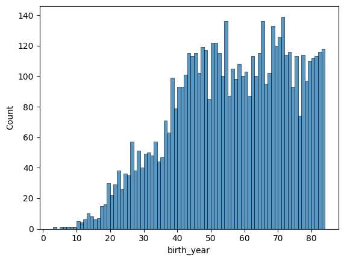

```python
sns.histplot(data_merge["birth_year"], binwidth=1)
plt.show()
```

### We can see as follows the distribution of political parties by self-identification and vice-versa, self-identification by political party.

```python
df_parties = data_merge[data_merge["political_party"].isin(["DPP", "KMT"])]
```

```
[Text(0.5, 0, 'Ethnic Identification')]
```

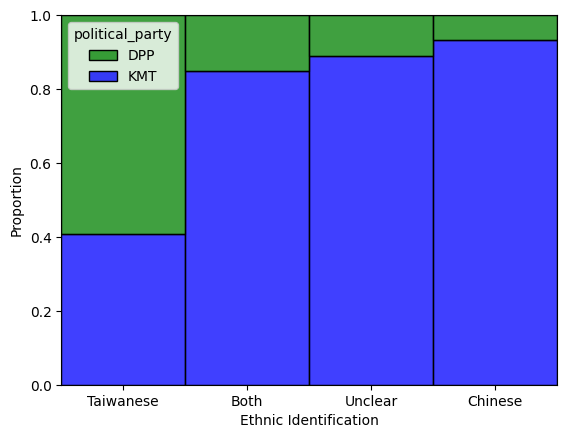

```python
color_palette_parties = {"DPP": "green", "KMT": "blue"}

ax = sns.histplot(
    data=data_merge,
    x="taiwanese_or_chinese",
    hue="political_party",
    hue_order=["DPP", "KMT"],
    multiple="fill",
    stat="proportion",
    palette=color_palette_parties,
)

ax.set(xlabel="Ethnic Identification")
```

```
[Text(0.5, 0, 'Political Party')]
```

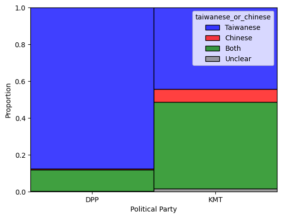

```python
color_palette_ethnic = {
    "Taiwanese": "blue",
    "Chinese": "red",
    "Both": "green",
    "Unclear": "gray",
}

ax = sns.histplot(
    data=df_parties,
    x="political_party",
    hue="taiwanese_or_chinese",
    hue_order=["Taiwanese", "Chinese", "Both", "Unclear"],
    multiple="fill",
    stat="proportion",
    palette=color_palette_ethnic,
)
ax.set(xlabel="Political Party")
```

People that identify as Chinese are more probable to vote KMT than other self-identifications.

Although the margin is small, KMT voters tend to have a significantly higher amount of people that self-identify as Chinese.

# Step 3: Machine Learning Classification

```python
from sklearn.ensemble import RandomForestClassifier
from sklearn.model_selection import train_test_split
from sklearn.preprocessing import OrdinalEncoder
from sklearn.metrics import accuracy_score, recall_score, f1_score, precision_score
```

### Before we begin building our models, we must eliminate unimportant values from our target column, such a political_party == 'Other'. This is because 'Other' is a majority class and could imbalance our classification model leading to subpar metrics.

```python
data_merge["political_party"].value_counts()
```

| political_party | count |
| --- | --- |
| Other | 4190 |
| KMT | 985 |
| DPP | 722 |

**dtype:** int64

```python
# Split the dataset into features (X) and target variable (y)
X = data_merge.drop(columns=["political_party"])  # Drop non-target columns
y = data_merge["political_party"]  # Create target variable


# Our models require us to encode the categories in our feature set
X_encoded = pd.get_dummies(X, columns=X.select_dtypes(include=["category"]).columns)
```

```
For the Random Forest predictor model:
 Accuracy 0.7584745762711864
 Recall is: 0.7584745762711864
 F1 Score: 0.7440251327485741
 Precision 0.7448811876197732
```

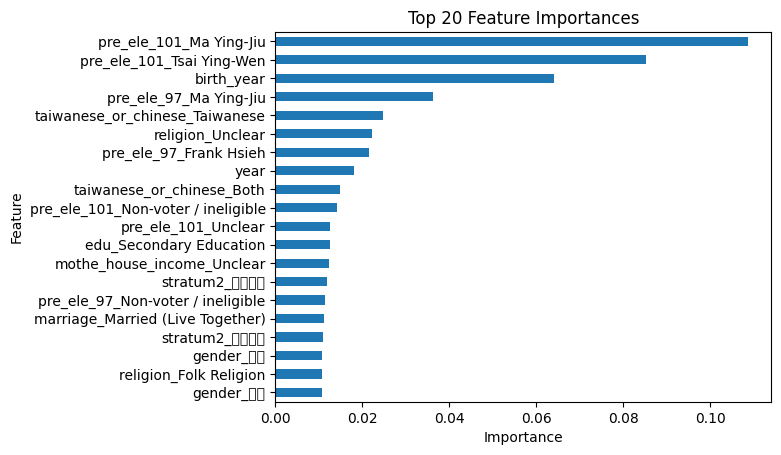

```python
# Split the dataset into training and testing sets
X_train, X_test, y_train, y_test = train_test_split(
    X_encoded, y, test_size=0.2, random_state=42
)

# Initialize the Random Forest classifier
rf_classifier = (
    RandomForestClassifier(class_weight="balanced", random_state=42)
)  # You can adjust the number of trees (n_estimators) and other hyperparameters

# Train the classifier on the training data
rf_classifier.fit(X_train, y_train)

# Make predictions on the test data
y_pred = rf_classifier.predict(X_test)

# Evaluate the accuracy of the classifier
accuracy = accuracy_score(y_test, y_pred)
recall = recall_score(y_test, y_pred, average="weighted")
f1 = f1_score(y_test, y_pred, average="weighted")
precision = precision_score(y_test, y_pred, average="weighted")
print(
    "For the Random Forest predictor model:",
    "\n Accuracy",
    accuracy,
    "\n Recall is:",
    recall,
    "\n F1 Score:",
    f1,
    "\n Precision",
    precision,
)

feat_importances = pd.Series(
    rf_classifier.feature_importances_, index=X_encoded.columns
)
ax = feat_importances.nlargest(20).plot(kind="barh")
ax.invert_yaxis()  # Invert y-axis
plt.title("Top 20 Feature Importances")
plt.xlabel("Importance")
plt.ylabel("Feature")
plt.show()  # Display the plot
```

### For the remaining of our modelling, we eliminate this 'Other' category.

```python
data_merge = data_merge[data_merge["political_party"] != "Other"]  # Eliminate the 'other' category
```

```python
# Split the dataset into features (X) and target variable (y)
X = data_merge.drop(columns=["political_party"])  # Drop non-target columns
y = data_merge["political_party"]  # Create target variable


# Our models require us to encode the categories in our feature set
X_encoded = pd.get_dummies(X, columns=X.select_dtypes(include=["category"]).columns)
```

```python
data_merge['political_party'].value_counts()
```

| political_party | count |
| --- | --- |
| KMT | 985 |
| DPP | 722 |
| Other | 0 |

**dtype:** int64

```
For the Random Forest predictor model:
 Accuracy 0.9269005847953217
 Recall is: 0.9269005847953217
 F1 Score: 0.9264832395998231
 Precision 0.9274137431660867
```

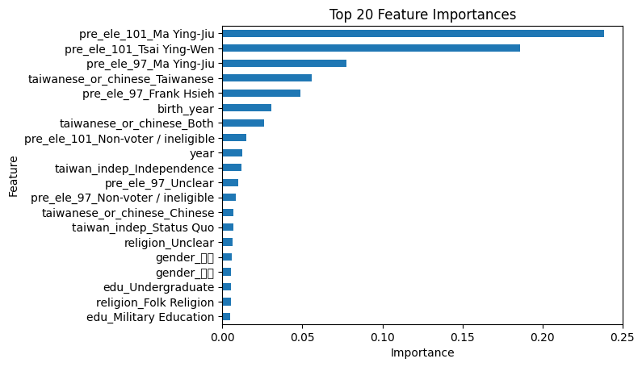

```python
# Split the dataset into training and testing sets
X_train, X_test, y_train, y_test = train_test_split(
    X_encoded, y, test_size=0.2, random_state=42
)

# Initialize the Random Forest classifier
rf_classifier = (
    RandomForestClassifier(class_weight="balanced", random_state=42)
)  # You can adjust the number of trees (n_estimators) and other hyperparameters

# Train the classifier on the training data
rf_classifier.fit(X_train, y_train)

# Make predictions on the test data
y_pred = rf_classifier.predict(X_test)

# Evaluate the accuracy of the classifier
accuracy = accuracy_score(y_test, y_pred)
recall = recall_score(y_test, y_pred, average="weighted")
f1 = f1_score(y_test, y_pred, average="weighted")
precision = precision_score(y_test, y_pred, average="weighted")
print(
    "For the Random Forest predictor model:",
    "\n Accuracy",
    accuracy,
    "\n Recall is:",
    recall,
    "\n F1 Score:",
    f1,
    "\n Precision",
    precision,
)

feat_importances = pd.Series(
    rf_classifier.feature_importances_, index=X_encoded.columns
)
ax = feat_importances.nlargest(20).plot(kind="barh")
ax.invert_yaxis()  # Invert y-axis
plt.title("Top 20 Feature Importances")
plt.xlabel("Importance")
plt.ylabel("Feature")
plt.show()  # Display the plot
```

```python
from sklearn.metrics import classification_report

print(classification_report(y_test, y_pred, target_names=["KMT", "DPP"]))
```

[output not shown]

Recall, precision and F1 Scores are much improved thanks to target feature simplification

### The cells below build a train/test split once and then compare a baseline tree, a pruned tree selected with 5-fold cross validation, a tuned random forest, and a tuned boosted tree.

```python
from sklearn.tree import DecisionTreeClassifier
from sklearn.ensemble import GradientBoostingClassifier, RandomForestClassifier
from sklearn.model_selection import RandomizedSearchCV, StratifiedKFold, cross_val_score, train_test_split
from sklearn.metrics import accuracy_score, f1_score, precision_score, recall_score

# Keep the binary target used in the existing modeling section
model_df = data_merge[data_merge["political_party"].isin(["DPP", "KMT"])].copy()
X_model = model_df.drop(columns=["political_party"])
y_model = model_df["political_party"]

# One-hot encode the cleaned categorical predictors
X_model_encoded = pd.get_dummies(
    X_model, columns=X_model.select_dtypes(include=["category", "object"]).columns
)

# Construct a single training set and test set for all model comparisons
X_train, X_test, y_train, y_test = train_test_split(
    X_model_encoded,
    y_model,
    test_size=0.2,
    random_state=42,
    stratify=y_model,
)

cv5 = StratifiedKFold(n_splits=5, shuffle=True, random_state=42)

print("Training rows:", len(X_train))
print("Test rows:", len(X_test))
print("Encoded feature count:", X_train.shape[1])
```

```
Training rows: 1365
Test rows: 342
Encoded feature count: 232
```

```python
# Baseline tree without pruning
baseline_tree = DecisionTreeClassifier(random_state=42)
baseline_tree.fit(X_train, y_train)
baseline_pred = baseline_tree.predict(X_test)

print("Baseline decision tree")
print("Accuracy:", accuracy_score(y_test, baseline_pred))
print("Recall:", recall_score(y_test, baseline_pred, average="weighted", zero_division=0))
print("F1 score:", f1_score(y_test, baseline_pred, average="weighted", zero_division=0))
print("Precision:", precision_score(y_test, baseline_pred, average="weighted", zero_division=0))
print("Tree depth:", baseline_tree.get_depth())
print("Tree leaves:", baseline_tree.get_n_leaves())
print("Tree splits:", baseline_tree.tree_.node_count - baseline_tree.get_n_leaves())
```

```
Baseline decision tree
Accuracy: 0.9152046783625731
Recall: 0.9152046783625731
F1 score: 0.9153134823593321
Precision: 0.9155651853698518
Tree depth: 17
Tree leaves: 100
Tree splits: 99
```

```python
# Cross-validated cost-complexity pruning
pruning_path_tree = DecisionTreeClassifier(random_state=42)
pruning_path = pruning_path_tree.cost_complexity_pruning_path(X_train, y_train)
ccp_alphas = np.unique(pruning_path.ccp_alphas)

# Drop the largest alpha because it usually collapses the tree to a single node
if len(ccp_alphas) > 1:
    ccp_alphas = ccp_alphas[:-1]

pruning_results = []
for alpha in ccp_alphas:
    candidate_tree = DecisionTreeClassifier(random_state=42, ccp_alpha=float(alpha))
    cv_scores = cross_val_score(
        candidate_tree,
        X_train,
        y_train,
        cv=cv5,
        scoring="accuracy",
        n_jobs=-1,
    )
    pruning_results.append(
        {
            "ccp_alpha": float(alpha),
            "mean_accuracy": cv_scores.mean(),
            "std_accuracy": cv_scores.std(),
        }
    )

pruning_results = pd.DataFrame(pruning_results)
best_row = pruning_results.loc[pruning_results["mean_accuracy"].idxmax()]

# One-standard-error rule: keep the simplest tree within one std of the best mean score
candidate_rows = pruning_results[
    pruning_results["mean_accuracy"] >= best_row["mean_accuracy"] - best_row["std_accuracy"]
]
chosen_row = candidate_rows.sort_values("ccp_alpha", ascending=False).iloc[0]
chosen_alpha = float(chosen_row["ccp_alpha"])

pruned_tree = DecisionTreeClassifier(random_state=42, ccp_alpha=chosen_alpha)
pruned_tree.fit(X_train, y_train)
pruned_pred = pruned_tree.predict(X_test)

print("Pruned decision tree")
print("Chosen ccp_alpha:", chosen_alpha)
print("Cross-val mean accuracy:", chosen_row["mean_accuracy"])
print("Cross-val std accuracy:", chosen_row["std_accuracy"])
print("Accuracy:", accuracy_score(y_test, pruned_pred))
print("Recall:", recall_score(y_test, pruned_pred, average="weighted", zero_division=0))
print("F1 score:", f1_score(y_test, pruned_pred, average="weighted", zero_division=0))
print("Precision:", precision_score(y_test, pruned_pred, average="weighted", zero_division=0))
print("Tree depth:", pruned_tree.get_depth())
print("Tree leaves:", pruned_tree.get_n_leaves())
print("Tree splits:", pruned_tree.tree_.node_count - pruned_tree.get_n_leaves())

print("Top pruning candidates by accuracy:")
print(pruning_results.sort_values(["mean_accuracy", "ccp_alpha"], ascending=[False, False]).head(10))
```

```
Pruned decision tree
Chosen ccp_alpha: 0.004447829126986602
Cross-val mean accuracy: 0.9113553113553113
Cross-val std accuracy: 0.02332847374079216
Accuracy: 0.8918128654970761
Recall: 0.8918128654970761
F1 score: 0.8924342826040528
Precision: 0.9011165365521083
Tree depth: 3
Tree leaves: 5
Tree splits: 4
Top pruning candidates by accuracy:
    ccp_alpha  mean_accuracy  std_accuracy
22   0.001583       0.921612      0.013227
28   0.003423       0.919414      0.017643
24   0.001693       0.919414      0.013308
23   0.001686       0.919414      0.013308
20   0.001251       0.918681      0.016283
27   0.002718       0.918681      0.018446
26   0.002016       0.918681      0.018735
25   0.001963       0.918681      0.018735
21   0.001364       0.917949      0.015983
18   0.001210       0.917216      0.015297
```

```python
# Random forest tuned with RandomizedSearchCV
rf_base = RandomForestClassifier(class_weight="balanced", random_state=42)
rf_param_distributions = {
    "n_estimators": [200, 300, 500, 700],
    "max_depth": [None, 10, 20, 30, 40],
    "min_samples_split": [2, 5, 10],
    "min_samples_leaf": [1, 2, 4],
    "max_features": [None, "sqrt", "log2"],
    "bootstrap": [True, False],
}

rf_search = RandomizedSearchCV(
    estimator=rf_base,
    param_distributions=rf_param_distributions,
    n_iter=20,
    cv=cv5,
    scoring="f1_weighted",
    random_state=42,
    n_jobs=-1,
    verbose=1,
)
rf_search.fit(X_train, y_train)
rf_best = rf_search.best_estimator_
rf_pred = rf_best.predict(X_test)

print("Random forest with RandomizedSearchCV")
print("Best parameters:", rf_search.best_params_)
print("Best CV score:", rf_search.best_score_)
print("Accuracy:", accuracy_score(y_test, rf_pred))
print("Recall:", recall_score(y_test, rf_pred, average="weighted", zero_division=0))
print("F1 score:", f1_score(y_test, rf_pred, average="weighted", zero_division=0))
print("Precision:", precision_score(y_test, rf_pred, average="weighted", zero_division=0))
print("Bagging-style option was available when max_features=None")
```

```
Fitting 5 folds for each of 20 candidates, totalling 100 fits
Random forest with RandomizedSearchCV
Best parameters: {'n_estimators': 500, 'min_samples_split': 2, 'min_samples_leaf': 2, 'max_features': 'sqrt', 'max_depth': 10, 'bootstrap': True}
Best CV score: 0.9335361386726324
Accuracy: 0.9298245614035088
Recall: 0.9298245614035088
F1 score: 0.9300804093567251
Precision: 0.9319369667916557
Bagging-style option was available when max_features=None
```

```python
# Boosted tree tuned with cross validation
boosted_tree = GradientBoostingClassifier(random_state=42)
boosted_param_distributions = {
    "n_estimators": [100, 150, 200, 300],
    "learning_rate": [0.01, 0.05, 0.1, 0.2],
    "max_depth": [1, 2, 3, 4],
    "min_samples_split": [2, 5, 10],
    "min_samples_leaf": [1, 2, 4],
    "subsample": [0.6, 0.8, 1.0],
    "max_features": [None, "sqrt", "log2"],
}

boosted_search = RandomizedSearchCV(
    estimator=boosted_tree,
    param_distributions=boosted_param_distributions,
    n_iter=20,
    cv=cv5,
    scoring="f1_weighted",
    random_state=42,
    n_jobs=-1,
    verbose=1,
)
boosted_search.fit(X_train, y_train)
boosted_best = boosted_search.best_estimator_
boosted_pred = boosted_best.predict(X_test)

print("Boosted tree with RandomizedSearchCV")
print("Best parameters:", boosted_search.best_params_)
print("Best CV score:", boosted_search.best_score_)
print("Accuracy:", accuracy_score(y_test, boosted_pred))
print("Recall:", recall_score(y_test, boosted_pred, average="weighted", zero_division=0))
print("F1 score:", f1_score(y_test, boosted_pred, average="weighted", zero_division=0))
print("Precision:", precision_score(y_test, boosted_pred, average="weighted", zero_division=0))
```

```
Fitting 5 folds for each of 20 candidates, totalling 100 fits
Boosted tree with RandomizedSearchCV
Best parameters: {'subsample': 0.8, 'n_estimators': 300, 'min_samples_split': 10, 'min_samples_leaf': 1, 'max_features': 'sqrt', 'max_depth': 2, 'learning_rate': 0.01}
Best CV score: 0.9265590305911893
Accuracy: 0.9298245614035088
Recall: 0.9298245614035088
F1 score: 0.9299932053594562
Precision: 0.9307406549034423
```

```python
!pip install xgboost catboost
```

```
Downloading catboost-1.2.10-cp312-cp312-manylinux2014_x86_64.whl (97.1 MB)
   ━━━━━━━━━━━━━━━━━━━━━━━━━━━━━━━━━━━━━━━━ 97.1/97.1 MB 6.0 MB/s eta 0:00:00
```

```python
from xgboost import XGBClassifier
from catboost import CatBoostClassifier
from sklearn.preprocessing import LabelEncoder
```

```python
# XGBoost requires numeric labels
le = LabelEncoder()
y_train_enc = le.fit_transform(y_train)
y_test_enc = le.transform(y_test)

# ── XGBoost ──────────────────────────────────────────────────────────────────
xgb_base = XGBClassifier(
    eval_metric="logloss",
    random_state=42,
    n_jobs=-1,
)
xgb_param_distributions = {
    "n_estimators": [100, 200, 300, 500],
    "learning_rate": [0.01, 0.05, 0.1, 0.2],
    "max_depth": [3, 4, 5, 6],
    "subsample": [0.6, 0.8, 1.0],
    "colsample_bytree": [0.6, 0.8, 1.0],
    "min_child_weight": [1, 3, 5],
    "gamma": [0, 0.1, 0.3],
}

xgb_search = RandomizedSearchCV(
    estimator=xgb_base,
    param_distributions=xgb_param_distributions,
    n_iter=20,
    cv=cv5,
    scoring="f1_weighted",
    random_state=42,
    n_jobs=-1,
    verbose=1,
)
xgb_search.fit(X_train, y_train_enc)
xgb_best = xgb_search.best_estimator_
xgb_pred = le.inverse_transform(xgb_best.predict(X_test))

print("XGBoost with RandomizedSearchCV")
print("Best parameters:", xgb_search.best_params_)
print("Best CV score:", xgb_search.best_score_)
print("Accuracy:", accuracy_score(y_test, xgb_pred))
print("Recall:", recall_score(y_test, xgb_pred, average="weighted", zero_division=0))
print("F1 score:", f1_score(y_test, xgb_pred, average="weighted", zero_division=0))
print("Precision:", precision_score(y_test, xgb_pred, average="weighted", zero_division=0))
```

```
Fitting 5 folds for each of 20 candidates, totalling 100 fits
XGBoost with RandomizedSearchCV
Best parameters: {'subsample': 0.6, 'n_estimators': 200, 'min_child_weight': 1, 'max_depth': 3, 'learning_rate': 0.1, 'gamma': 0.3, 'colsample_bytree': 0.8}
Best CV score: 0.9266429194007776
Accuracy: 0.9473684210526315
Recall: 0.9473684210526315
F1 score: 0.9475294802363908
Precision: 0.948737129679682
```

```python
cb_base = CatBoostClassifier(
    random_state=42,
    verbose=0,
)
cb_param_distributions = {
    "iterations": [100, 200, 300, 500],
    "learning_rate": [0.01, 0.05, 0.1, 0.2],
    "depth": [3, 4, 5, 6],
    "l2_leaf_reg": [1, 3, 5, 7],
    "subsample": [0.6, 0.8, 1.0],
    "colsample_bylevel": [0.6, 0.8, 1.0],
}

cb_search = RandomizedSearchCV(
    estimator=cb_base,
    param_distributions=cb_param_distributions,
    n_iter=20,
    cv=cv5,
    scoring="f1_weighted",
    random_state=42,
    n_jobs=-1,
    verbose=1,
)
cb_search.fit(X_train, y_train)
cb_best = cb_search.best_estimator_
cb_pred = cb_best.predict(X_test)

print("CatBoost with RandomizedSearchCV")
print("Best parameters:", cb_search.best_params_)
print("Best CV score:", cb_search.best_score_)
print("Accuracy:", accuracy_score(y_test, cb_pred))
print("Recall:", recall_score(y_test, cb_pred, average="weighted", zero_division=0))
print("F1 score:", f1_score(y_test, cb_pred, average="weighted", zero_division=0))
print("Precision:", precision_score(y_test, cb_pred, average="weighted", zero_division=0))
```

```
Fitting 5 folds for each of 20 candidates, totalling 100 fits
CatBoost with RandomizedSearchCV
Best parameters: {'subsample': 1.0, 'learning_rate': 0.1, 'l2_leaf_reg': 5, 'iterations': 100, 'depth': 5, 'colsample_bylevel': 0.8}
Best CV score: 0.9281562013073084
Accuracy: 0.9444444444444444
Recall: 0.9444444444444444
F1 score: 0.9445582133918154
Precision: 0.9450810185185186
```

```python
summary = pd.DataFrame(
    {
        "Model": [
            "Baseline Tree",
            "Pruned Tree",
            "Random Forest",
            "Gradient Boosting",
            "XGBoost",
            "CatBoost",
        ],
        "Accuracy": [
            accuracy_score(y_test, baseline_pred),
            accuracy_score(y_test, pruned_pred),
            accuracy_score(y_test, rf_pred),
            accuracy_score(y_test, boosted_pred),
            accuracy_score(y_test, xgb_pred),
            accuracy_score(y_test, cb_pred),
        ],
        "F1 (weighted)": [
            f1_score(y_test, baseline_pred, average="weighted", zero_division=0),
            f1_score(y_test, pruned_pred, average="weighted", zero_division=0),
            f1_score(y_test, rf_pred, average="weighted", zero_division=0),
            f1_score(y_test, boosted_pred, average="weighted", zero_division=0),
            f1_score(y_test, xgb_pred, average="weighted", zero_division=0),
            f1_score(y_test, cb_pred, average="weighted", zero_division=0),
        ],
        "Precision": [
            precision_score(y_test, baseline_pred, average="weighted", zero_division=0),
            precision_score(y_test, pruned_pred, average="weighted", zero_division=0),
            precision_score(y_test, rf_pred, average="weighted", zero_division=0),
            precision_score(y_test, boosted_pred, average="weighted", zero_division=0),
            precision_score(y_test, xgb_pred, average="weighted", zero_division=0),
            precision_score(y_test, cb_pred, average="weighted", zero_division=0),
        ],
        "Recall": [
            recall_score(y_test, baseline_pred, average="weighted", zero_division=0),
            recall_score(y_test, pruned_pred, average="weighted", zero_division=0),
            recall_score(y_test, rf_pred, average="weighted", zero_division=0),
            recall_score(y_test, boosted_pred, average="weighted", zero_division=0),
            recall_score(y_test, xgb_pred, average="weighted", zero_division=0),
            recall_score(y_test, cb_pred, average="weighted", zero_division=0),
        ],
    }
).set_index("Model").round(4)

print(summary.sort_values("F1 (weighted)", ascending=False).to_string())
```

```
                   Accuracy  F1 (weighted)  Precision  Recall
Model
XGBoost              0.9474         0.9475     0.9487  0.9474
CatBoost             0.9444         0.9446     0.9451  0.9444
Random Forest        0.9298         0.9301     0.9319  0.9298
Gradient Boosting    0.9298         0.9300     0.9307  0.9298
Baseline Tree        0.9152         0.9153     0.9156  0.9152
Pruned Tree          0.8918         0.8924     0.9011  0.8918
```

# Section 4: Feature Importances

Feature Importance

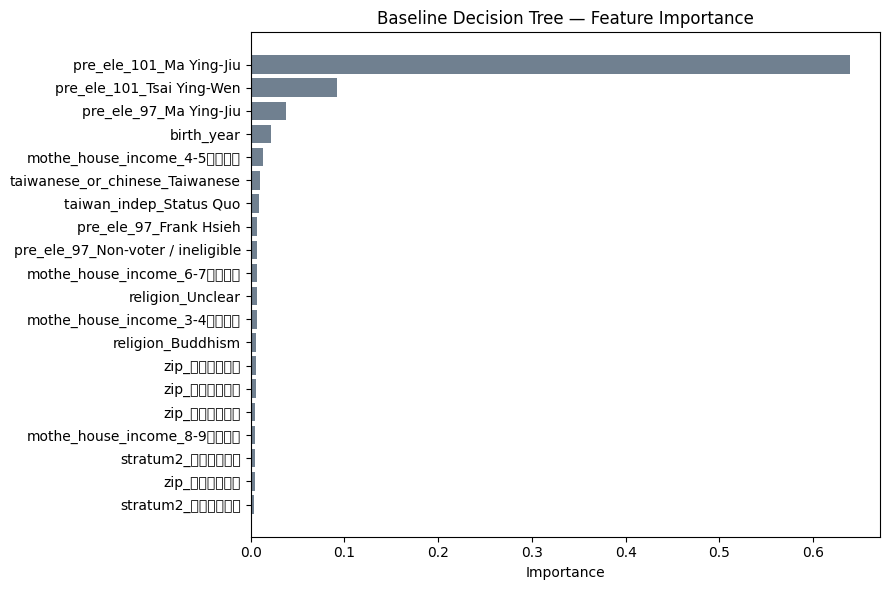

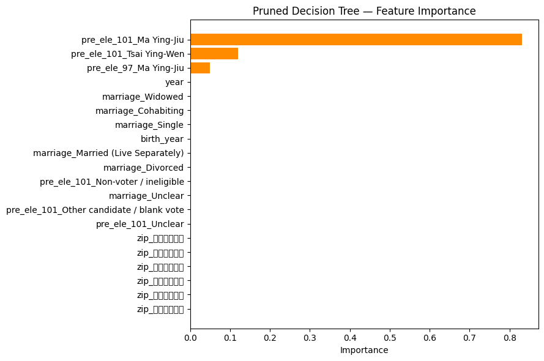

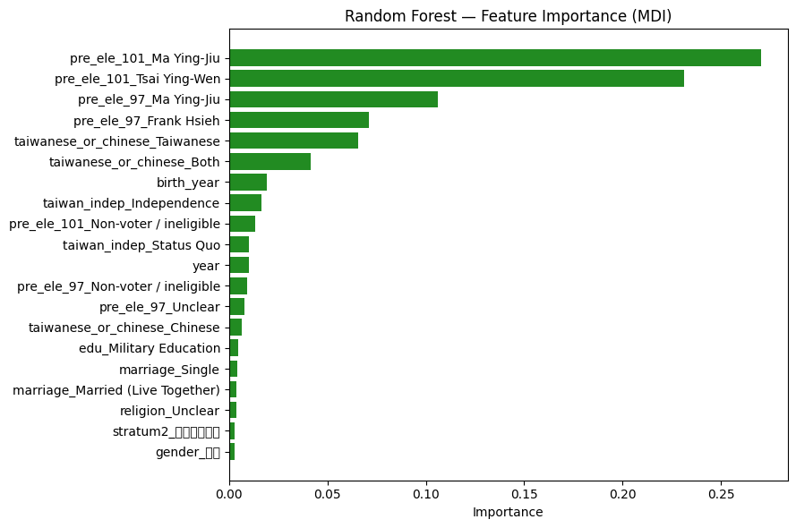

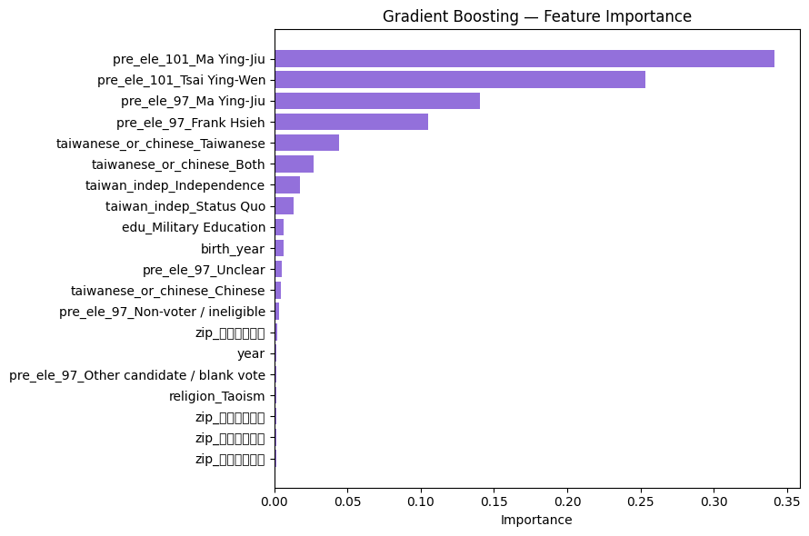

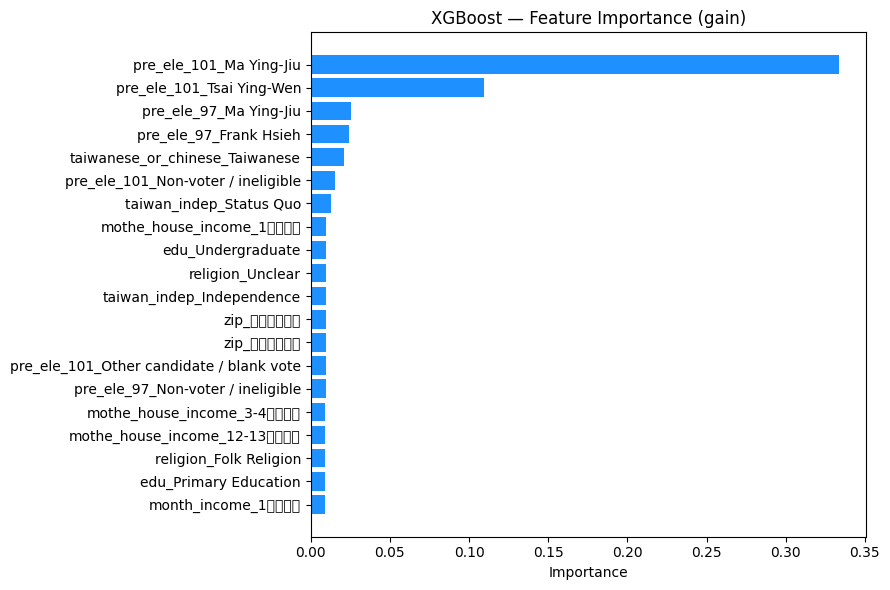

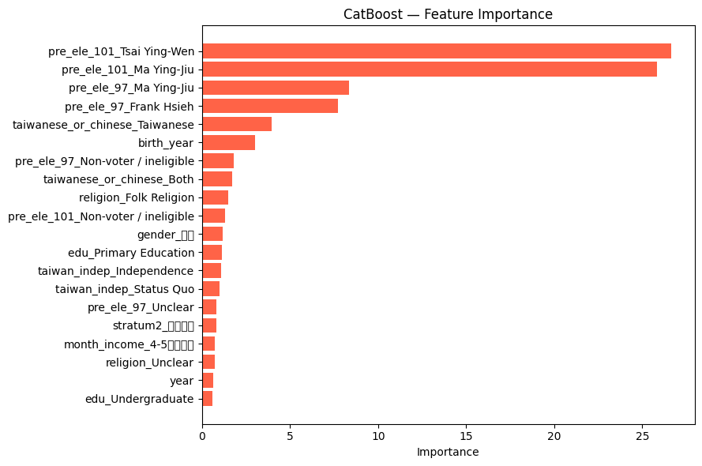

|  | feature | importance |
| --- | --- | --- |
| 10 | pre_ele_101_Tsai Ying-Wen | 26.657654 |
| 11 | pre_ele_101_Ma Ying-Jiu | 25.818122 |
| 164 | pre_ele_97_Ma Ying-Jiu | 8.356385 |
| 163 | pre_ele_97_Frank Hsieh | 7.713301 |
| 147 | taiwanese_or_chinese_Taiwanese | 3.932284 |
| 1 | birth_year | 3.005329 |
| 162 | pre_ele_97_Non-voter / ineligible | 1.817301 |
| 148 | taiwanese_or_chinese_Both | 1.700628 |
| 140 | religion_Folk Religion | 1.469655 |
| 9 | pre_ele_101_Non-voter / ineligible | 1.295527 |
| 161 | gender_女性 | 1.161260 |
| 153 | edu_Primary Education | 1.140521 |
| 229 | taiwan_indep_Independence | 1.072023 |
| 228 | taiwan_indep_Status Quo | 1.014397 |
| 165 | pre_ele_97_Unclear | 0.819653 |
| 195 | stratum2_工商市區 | 0.800962 |
| 205 | month_income_4-5萬元以下 | 0.744680 |
| 145 | religion_Unclear | 0.735292 |
| 0 | year | 0.641573 |
| 157 | edu_Undergraduate | 0.568833 |

```python
from IPython.display import Markdown, display
display(Markdown("# Feature Importance"))

feature_names = X_train.columns.tolist()

def plot_feature_importance(importances, feature_names, title, top_n=20, color="steelblue"):
    fi_df = (
        pd.DataFrame({"feature": feature_names, "importance": importances})
        .sort_values("importance", ascending=False)
        .head(top_n)
    )
    fig, ax = plt.subplots(figsize=(9, 6))
    ax.barh(fi_df["feature"][::-1], fi_df["importance"][::-1], color=color)
    ax.set_xlabel("Importance")
    ax.set_title(title)
    plt.tight_layout()
    plt.show()
    return fi_df

# ── Baseline Decision Tree ────────────────────────────────────────────────────
plot_feature_importance(
    baseline_tree.feature_importances_,
    feature_names,
    "Baseline Decision Tree — Feature Importance",
    color="slategray",
)

# ── Pruned Decision Tree ──────────────────────────────────────────────────────
plot_feature_importance(
    pruned_tree.feature_importances_,
    feature_names,
    "Pruned Decision Tree — Feature Importance",
    color="darkorange",
)

# ── Random Forest ─────────────────────────────────────────────────────────────
plot_feature_importance(
    rf_best.feature_importances_,
    feature_names,
    "Random Forest — Feature Importance (MDI)",
    color="forestgreen",
)

# ── Gradient Boosting ─────────────────────────────────────────────────────────
plot_feature_importance(
    boosted_best.feature_importances_,
    feature_names,
    "Gradient Boosting — Feature Importance",
    color="mediumpurple",
)

# ── XGBoost ───────────────────────────────────────────────────────────────────
plot_feature_importance(
    xgb_best.feature_importances_,
    feature_names,
    "XGBoost — Feature Importance (gain)",
    color="dodgerblue",
)

# ── CatBoost ──────────────────────────────────────────────────────────────────
plot_feature_importance(
    cb_best.feature_importances_,
    feature_names,
    "CatBoost — Feature Importance",
    color="tomato",
)
```

### We can see from the above results that the most related predictor of party affiliation is, unsurprisingly, voting history. In this case, voters of Ma Ying-Jiu tend to align themselves more to the KMT, while voters of other candidates and, more strongly, past voters for DPP candidates align themselves with the DPP.

### As well, it can be emphasized almost how much of an effect ethnic/national self-identification has on party alignment. Here people who regard themselves as Taiwanese, in opposition to Chinese or both Taiwanese and Chinese, tend to be positively correlated with DPP alignment. Whereas, people regarding themselves as Chinese or both Taiwanese and Chinese tend to align themselves more with the KMT Party

### Same trend seems to happen for stances on Taiwanese independence. DPP supporters seem to tend more likely to support independence, while KMT supporters prefer unification. It is worth to note that supporting Status Quo on Taiwanese independence seems to be more positively correlated with KMT alignment.

### Most general demographics seem to not be as important to our Random Tree model.

### We can run a logistic regression model isolating each feature and our target to see how the above important features relate with our target. For example, does birth_year relate positively or negatively with our target in each model (i.e Does higher birth_year (younger) result in positive or negative correlation to, say, KMT?)

```python
isolated_features = [
    "birth_year",
    "taiwanese_or_chinese",
    "pre_ele_101",
    "pre_ele_97",
    "taiwan_indep",
]

X_isolated_features = pd.DataFrame(X, columns=isolated_features)

X_isolated_features = pd.get_dummies(
    X_isolated_features,
    columns=X_isolated_features.select_dtypes(include=["category"]).columns,
)

y_by_target = pd.get_dummies(y).astype("int")
```

```python
from sklearn.linear_model import LogisticRegression
from scipy.stats import pearsonr

positive_coefficients = []
negative_coefficients = []

for column_y in y_by_target.columns:
    if column_y != "Other":
        for column_X in X_isolated_features.columns:

            current_feature = X_isolated_features[column_X]
            current_target = y_by_target[column_y]

            # Build a simple linear regression model
            model = LogisticRegression()
            model.fit(current_feature.to_frame(), current_target)

            # Print the intercept and coefficient
            # print(f"Intercept: {model.intercept_}")
            # print(f"Coefficient for {column_X} on {column_y}: {model.coef_[0]}  \n")

            if model.coef_[0] > 0.90:
                positive_coefficients.append([column_X, model.coef_[0]])
            elif model.coef_[0] < -0.90:
                negative_coefficients.append([column_X, model.coef_[0]])

        # Print features with positive and negative coefficients
        print(
            f"\n The features with positive correlation with our target {column_y} are:"
        )
        for coef in positive_coefficients:
            print(f"{coef[0]} with coefficient {coef[1]}")

        print(
            f"\n The features with negative correlation with our target {column_y} are:"
        )
        for coef in negative_coefficients:
            print(f"{coef[0]} with coefficient {coef[1]}")

        positive_coefficients = []
        negative_coefficients = []
```

```
 The features with positive correlation with our target DPP are:
taiwanese_or_chinese_Taiwanese with coefficient [2.14237866]
pre_ele_101_Tsai Ying-Wen with coefficient [4.95874806]
pre_ele_97_Frank Hsieh with coefficient [4.12821962]
pre_ele_97_Other candidate / blank vote with coefficient [1.00546181]
taiwan_indep_Independence with coefficient [2.01266087]

 The features with negative correlation with our target DPP are:
taiwanese_or_chinese_Both with coefficient [-1.8898267]
taiwanese_or_chinese_Unclear with coefficient [-1.22438327]
taiwanese_or_chinese_Chinese with coefficient [-2.00574056]
pre_ele_101_Ma Ying-Jiu with coefficient [-4.82312458]
pre_ele_97_Ma Ying-Jiu with coefficient [-3.27012106]
taiwan_indep_Status Quo with coefficient [-1.005583]
taiwan_indep_Unification with coefficient [-0.9783651]

 The features with positive correlation with our target KMT are:
taiwanese_or_chinese_Both with coefficient [1.8898267]
taiwanese_or_chinese_Unclear with coefficient [1.22438327]
taiwanese_or_chinese_Chinese with coefficient [2.00574056]
pre_ele_101_Ma Ying-Jiu with coefficient [4.82312458]
pre_ele_97_Ma Ying-Jiu with coefficient [3.27012106]
taiwan_indep_Status Quo with coefficient [1.005583]
taiwan_indep_Unification with coefficient [0.9783651]

 The features with negative correlation with our target KMT are:
taiwanese_or_chinese_Taiwanese with coefficient [-2.14237866]
pre_ele_101_Tsai Ying-Wen with coefficient [-4.95874806]
pre_ele_97_Frank Hsieh with coefficient [-4.12821962]
pre_ele_97_Other candidate / blank vote with coefficient [-1.00546181]
taiwan_indep_Independence with coefficient [-2.01266087]
```

# Final Insights from Machine Learning Models

Based on the comprehensive modeling and correlation analysis above, we can draw the following key conclusions:

1. **Model Performance Hierarchy**: Advanced gradient boosting frameworks (XGBoost and CatBoost) outperformed the standard Random Forest and simple Decision Trees. XGBoost achieved the highest accuracy and F1 score (~94.7%), showing that iterative error correction on this dataset yields highly accurate partisan predictions.
2. **Dominance of Past Voting Behavior**: Across all tree-based models, `pre_ele_101` and `pre_ele_97` (past presidential voting choices) consistently ranked as the most important features by a massive margin. Partisan loyalty is extremely sticky; how an individual voted in previous elections is the strongest predictor of their baseline party affiliation.
3. **Ideological and Identity Polarization**: The logistic regression coefficients perfectly map the core ideological divides between the two major parties.
   - **DPP Alignment** is highly correlated with self-identifying exclusively as "Taiwanese" and supporting Taiwanese "Independence".
   - **KMT Alignment** is highly correlated with identifying as "Both" (Taiwanese and Chinese) or "Chinese", and supporting either the "Status Quo" or "Unification".
4. **Demographics vs. Ideology**: General demographics like birth year, marriage status, and income showed surprisingly little weight compared to identity and historical voting patterns, implying that Taiwanese political affiliation is driven much more by national identity issues than standard socioeconomic dividing lines.